# Project-1

```python
pip install pandas
```

[output not shown]

[output cut: 24 more lines]

[output not shown]

```python
pip install matplotlib
```

[output not shown]

[output not shown]

```python
pip install seaborn
```

```
Downloading seaborn-0.13.2-py3-none-any.whl (294 kB)
```

```python
# Import all the necessory libraries
import numpy as np
import pandas as pd # data processing, CSV file I/O (e.g. pd.read_csv)

import matplotlib.pyplot as plt #visualization
%matplotlib inline

import seaborn as sns #visualization
#import plotly.offline as py #visualization
#import plotly.graph_objs as go #visualization
import warnings

warnings.filterwarnings("ignore")
```

##### Importing the data

```python
data = pd.read_csv("E-Commerce Churn Data.csv")
data
```

|  | CustomerID | Churn | Tenure | PreferredLoginDevice | CityTier | WarehouseToHome | PreferredPaymentMode | Gender | HourSpendOnApp | NumberOfDeviceRegistered | PreferedOrderCat | SatisfactionScore | MaritalStatus | NumberOfAddress | Complain | OrderAmountHikeFromlastYear | CouponUsed | OrderCount | DaySinceLastOrder | CashbackAmount |
| --- | --- | --- | --- | --- | --- | --- | --- | --- | --- | --- | --- | --- | --- | --- | --- | --- | --- | --- | --- | --- |
| 0 | 50001 | 1 | 4.0 | Mobile Phone | 3 | 6.0 | Debit Card | Female | 3.0 | 3 | Laptop & Accessory | 2 | Single | 9 | 1 | 11.0 | 1.0 | 1.0 | 5.0 | 160 |
| 1 | 50002 | 1 | NaN | Phone | 1 | 8.0 | UPI | Male | 3.0 | 4 | Mobile | 3 | Single | 7 | 1 | 15.0 | 0.0 | 1.0 | 0.0 | 121 |
| 2 | 50003 | 1 | NaN | Phone | 1 | 30.0 | Debit Card | Male | 2.0 | 4 | Mobile | 3 | Single | 6 | 1 | 14.0 | 0.0 | 1.0 | 3.0 | 120 |
| 3 | 50004 | 1 | 0.0 | Phone | 3 | 15.0 | Debit Card | Male | 2.0 | 4 | Laptop & Accessory | 5 | Single | 8 | 0 | 23.0 | 0.0 | 1.0 | 3.0 | 134 |
| 4 | 50005 | 1 | 0.0 | Phone | 1 | 12.0 | CC | Male | NaN | 3 | Mobile | 5 | Single | 3 | 0 | 11.0 | 1.0 | 1.0 | 3.0 | 130 |
| ... | ... | ... | ... | ... | ... | ... | ... | ... | ... | ... | ... | ... | ... | ... | ... | ... | ... | ... | ... | ... |
| 5625 | 55626 | 0 | 10.0 | Computer | 1 | 30.0 | Credit Card | Male | 3.0 | 2 | Laptop & Accessory | 1 | Married | 6 | 0 | 18.0 | 1.0 | 2.0 | 4.0 | 151 |
| 5626 | 55627 | 0 | 13.0 | Mobile Phone | 1 | 13.0 | Credit Card | Male | 3.0 | 5 | Fashion | 5 | Married | 6 | 0 | 16.0 | 1.0 | 2.0 | NaN | 225 |
| 5627 | 55628 | 0 | 1.0 | Mobile Phone | 1 | 11.0 | Debit Card | Male | 3.0 | 2 | Laptop & Accessory | 4 | Married | 3 | 1 | 21.0 | 1.0 | 2.0 | 4.0 | 186 |
| 5628 | 55629 | 0 | 23.0 | Computer | 3 | 9.0 | Credit Card | Male | 4.0 | 5 | Laptop & Accessory | 4 | Married | 4 | 0 | 15.0 | 2.0 | 2.0 | 9.0 | 179 |
| 5629 | 55630 | 0 | 8.0 | Mobile Phone | 1 | 15.0 | Credit Card | Male | 3.0 | 2 | Laptop & Accessory | 3 | Married | 4 | 0 | 13.0 | 2.0 | 2.0 | 3.0 | 169 |

5630 rows × 20 columns

```python
# data information
data.info()
```

```
<class 'pandas.core.frame.DataFrame'>
RangeIndex: 5630 entries, 0 to 5629
Data columns (total 20 columns):
 #   Column                       Non-Null Count  Dtype
---  ------                       --------------  -----
 0   CustomerID                   5630 non-null   int64
 1   Churn                        5630 non-null   int64
 2   Tenure                       5366 non-null   float64
 3   PreferredLoginDevice         5630 non-null   object
 4   CityTier                     5630 non-null   int64
 5   WarehouseToHome              5379 non-null   float64
 6   PreferredPaymentMode         5630 non-null   object
 7   Gender                       5630 non-null   object
 8   HourSpendOnApp               5375 non-null   float64
 9   NumberOfDeviceRegistered     5630 non-null   int64
 10  PreferedOrderCat             5630 non-null   object
 11  SatisfactionScore            5630 non-null   int64
 12  MaritalStatus                5630 non-null   object
 13  NumberOfAddress              5630 non-null   int64
 14  Complain                     5630 non-null   int64
 15  OrderAmountHikeFromlastYear  5365 non-null   float64
 16  CouponUsed                   5374 non-null   float64
 17  OrderCount                   5372 non-null   float64
 18  DaySinceLastOrder            5323 non-null   float64
 19  CashbackAmount               5630 non-null   int64
dtypes: float64(7), int64(8), object(5)
memory usage: 879.8+ KB
```

b. Data Cleaning

Handle missing values

Convert categorical variables into numerical representations (for machine learning model)

```python
# check for the missing values
data.isnull().sum()
```

```
CustomerID                       0
Churn                            0
Tenure                         264
PreferredLoginDevice             0
CityTier                         0
WarehouseToHome                251
PreferredPaymentMode             0
Gender                           0
HourSpendOnApp                 255
NumberOfDeviceRegistered         0
PreferedOrderCat                 0
SatisfactionScore                0
MaritalStatus                    0
NumberOfAddress                  0
Complain                         0
OrderAmountHikeFromlastYear    265
CouponUsed                     256
OrderCount                     258
DaySinceLastOrder              307
CashbackAmount                   0
dtype: int64
```

```python
print(data['Tenure'].unique())
```

```
[ 4. nan  0. 13. 11.  9. 19. 20. 14.  8. 18.  5.  2. 30.  1. 23.  3. 29.
  6. 26. 28.  7. 24. 25. 10. 15. 22. 27. 16. 12. 21. 17. 50. 60. 31. 51.
 61.]
```

```python
# List of columns with missing data
missing_data_columns = [
    'Tenure',
    'WarehouseToHome',
    'HourSpendOnApp',
    'OrderAmountHikeFromlastYear',
    'CouponUsed',
    'OrderCount',
    'DaySinceLastOrder'
]

# Replace missing values with 0 in the specified columns
data[missing_data_columns] = data[missing_data_columns].fillna(0)

# Optionally, save the updated DataFrame to a new CSV file
data.to_csv('updated_dataset.csv', index=False)

# Display the first few rows of the updated DataFrame to confirm changes
print(data.head())
```

```
   CustomerID  Churn  Tenure PreferredLoginDevice  CityTier  WarehouseToHome  \
0       50001      1     4.0         Mobile Phone         3              6.0
1       50002      1     0.0                Phone         1              8.0
2       50003      1     0.0                Phone         1             30.0
3       50004      1     0.0                Phone         3             15.0
4       50005      1     0.0                Phone         1             12.0

  PreferredPaymentMode  Gender  HourSpendOnApp  NumberOfDeviceRegistered  \
0           Debit Card  Female             3.0                         3
1                  UPI    Male             3.0                         4
2           Debit Card    Male             2.0                         4
3           Debit Card    Male             2.0                         4
4                   CC    Male             0.0                         3

     PreferedOrderCat  SatisfactionScore MaritalStatus  NumberOfAddress  \
```

[output cut: 19 more lines]

```python
# checking for the missing values again
data.isnull().sum()
```

```
CustomerID                     0
Churn                          0
Tenure                         0
PreferredLoginDevice           0
CityTier                       0
WarehouseToHome                0
PreferredPaymentMode           0
Gender                         0
HourSpendOnApp                 0
NumberOfDeviceRegistered       0
PreferedOrderCat               0
SatisfactionScore              0
MaritalStatus                  0
NumberOfAddress                0
Complain                       0
OrderAmountHikeFromlastYear    0
CouponUsed                     0
OrderCount                     0
DaySinceLastOrder              0
CashbackAmount                 0
dtype: int64
```

```python
import pandas as pd

# Example DataFrame
# data = pd.read_csv('your_file.csv')  # Load your DataFrame

# Check for duplicates
duplicates = data[data.duplicated()]

# Display duplicates
print(duplicates)
```

[output not shown]

```python
# Count duplicates based on specific columns
num_duplicates_specific = data.duplicated(subset=['CustomerID']).sum()

# Display the count of duplicates
print(f"Total number of duplicate rows based on specific columns: {num_duplicates_specific}")
```

```
Total number of duplicate rows based on specific columns: 0
```

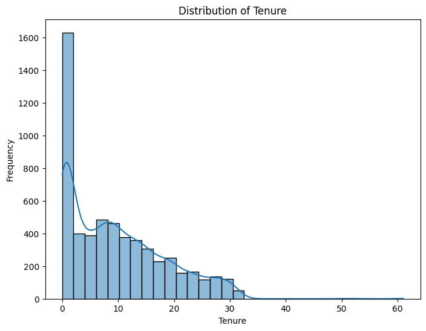

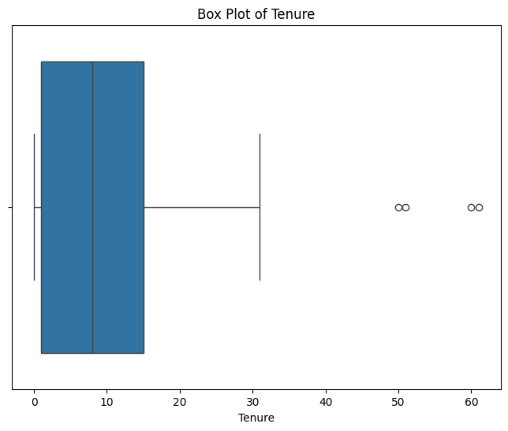

```python
# Histogram to check distribution of Tenure
plt.figure(figsize=(8, 6))
sns.histplot(data['Tenure'].dropna(), kde=True, bins=30)
plt.title('Distribution of Tenure')
plt.xlabel('Tenure')
plt.ylabel('Frequency')
plt.show()

# Box plot to visualize spread and outliers
plt.figure(figsize=(8, 6))
sns.boxplot(x=data['Tenure'])
plt.title('Box Plot of Tenure')
plt.show()
```

```python
data.head(5)
```

|  | CustomerID | Churn | Tenure | PreferredLoginDevice | CityTier | WarehouseToHome | PreferredPaymentMode | Gender | HourSpendOnApp | NumberOfDeviceRegistered | PreferedOrderCat | SatisfactionScore | MaritalStatus | NumberOfAddress | Complain | OrderAmountHikeFromlastYear | CouponUsed | OrderCount | DaySinceLastOrder | CashbackAmount |
| --- | --- | --- | --- | --- | --- | --- | --- | --- | --- | --- | --- | --- | --- | --- | --- | --- | --- | --- | --- | --- |
| 0 | 50001 | 1 | 4.0 | Mobile Phone | 3 | 6.0 | Debit Card | Female | 3.0 | 3 | Laptop & Accessory | 2 | Single | 9 | 1 | 11.0 | 1.0 | 1.0 | 5.0 | 160 |
| 1 | 50002 | 1 | 0.0 | Phone | 1 | 8.0 | UPI | Male | 3.0 | 4 | Mobile | 3 | Single | 7 | 1 | 15.0 | 0.0 | 1.0 | 0.0 | 121 |
| 2 | 50003 | 1 | 0.0 | Phone | 1 | 30.0 | Debit Card | Male | 2.0 | 4 | Mobile | 3 | Single | 6 | 1 | 14.0 | 0.0 | 1.0 | 3.0 | 120 |
| 3 | 50004 | 1 | 0.0 | Phone | 3 | 15.0 | Debit Card | Male | 2.0 | 4 | Laptop & Accessory | 5 | Single | 8 | 0 | 23.0 | 0.0 | 1.0 | 3.0 | 134 |
| 4 | 50005 | 1 | 0.0 | Phone | 1 | 12.0 | CC | Male | 0.0 | 3 | Mobile | 5 | Single | 3 | 0 | 11.0 | 1.0 | 1.0 | 3.0 | 130 |

```python
# Check for rows with NaN in the 'Tenure' column
missing_tenure_rows = data[data['Tenure'].isnull()]
print(missing_tenure_rows)
```

```
Empty DataFrame
Columns: [CustomerID, Churn, Tenure, PreferredLoginDevice, CityTier, WarehouseToHome, PreferredPaymentMode, Gender, HourSpendOnApp, NumberOfDeviceRegistered, PreferedOrderCat, SatisfactionScore, MaritalStatus, NumberOfAddress, Complain, OrderAmountHikeFromlastYear, CouponUsed, OrderCount, DaySinceLa…
Index: []
```

```python
data
```

|  | CustomerID | Churn | Tenure | PreferredLoginDevice | CityTier | WarehouseToHome | PreferredPaymentMode | Gender | HourSpendOnApp | NumberOfDeviceRegistered | PreferedOrderCat | SatisfactionScore | MaritalStatus | NumberOfAddress | Complain | OrderAmountHikeFromlastYear | CouponUsed | OrderCount | DaySinceLastOrder | CashbackAmount |
| --- | --- | --- | --- | --- | --- | --- | --- | --- | --- | --- | --- | --- | --- | --- | --- | --- | --- | --- | --- | --- |
| 0 | 50001 | 1 | 4.0 | Mobile Phone | 3 | 6.0 | Debit Card | Female | 3.0 | 3 | Laptop & Accessory | 2 | Single | 9 | 1 | 11.0 | 1.0 | 1.0 | 5.0 | 160 |
| 1 | 50002 | 1 | 0.0 | Phone | 1 | 8.0 | UPI | Male | 3.0 | 4 | Mobile | 3 | Single | 7 | 1 | 15.0 | 0.0 | 1.0 | 0.0 | 121 |
| 2 | 50003 | 1 | 0.0 | Phone | 1 | 30.0 | Debit Card | Male | 2.0 | 4 | Mobile | 3 | Single | 6 | 1 | 14.0 | 0.0 | 1.0 | 3.0 | 120 |
| 3 | 50004 | 1 | 0.0 | Phone | 3 | 15.0 | Debit Card | Male | 2.0 | 4 | Laptop & Accessory | 5 | Single | 8 | 0 | 23.0 | 0.0 | 1.0 | 3.0 | 134 |
| 4 | 50005 | 1 | 0.0 | Phone | 1 | 12.0 | CC | Male | 0.0 | 3 | Mobile | 5 | Single | 3 | 0 | 11.0 | 1.0 | 1.0 | 3.0 | 130 |
| ... | ... | ... | ... | ... | ... | ... | ... | ... | ... | ... | ... | ... | ... | ... | ... | ... | ... | ... | ... | ... |
| 5625 | 55626 | 0 | 10.0 | Computer | 1 | 30.0 | Credit Card | Male | 3.0 | 2 | Laptop & Accessory | 1 | Married | 6 | 0 | 18.0 | 1.0 | 2.0 | 4.0 | 151 |
| 5626 | 55627 | 0 | 13.0 | Mobile Phone | 1 | 13.0 | Credit Card | Male | 3.0 | 5 | Fashion | 5 | Married | 6 | 0 | 16.0 | 1.0 | 2.0 | 0.0 | 225 |
| 5627 | 55628 | 0 | 1.0 | Mobile Phone | 1 | 11.0 | Debit Card | Male | 3.0 | 2 | Laptop & Accessory | 4 | Married | 3 | 1 | 21.0 | 1.0 | 2.0 | 4.0 | 186 |
| 5628 | 55629 | 0 | 23.0 | Computer | 3 | 9.0 | Credit Card | Male | 4.0 | 5 | Laptop & Accessory | 4 | Married | 4 | 0 | 15.0 | 2.0 | 2.0 | 9.0 | 179 |
| 5629 | 55630 | 0 | 8.0 | Mobile Phone | 1 | 15.0 | Credit Card | Male | 3.0 | 2 | Laptop & Accessory | 3 | Married | 4 | 0 | 13.0 | 2.0 | 2.0 | 3.0 | 169 |

5630 rows × 20 columns

```python
print(data['Tenure'].unique())
```

```
[ 4.  0. 13. 11.  9. 19. 20. 14.  8. 18.  5.  2. 30.  1. 23.  3. 29.  6.
 26. 28.  7. 24. 25. 10. 15. 22. 27. 16. 12. 21. 17. 50. 60. 31. 51. 61.]
```

b. Data Cleaning

Handle missing values

Convert categorical variables into numerical representations (for machine learning model)

```python
import pandas as pd

# List all categorical columns that need to be encoded
categorical_columns = ['PreferredLoginDevice', 'PreferredPaymentMode', 'Gender', 'MaritalStatus', 'PreferedOrderCat', 'CityTier']

# Convert categorical columns to numerical using get_dummies
data_encoded = pd.get_dummies(data, columns=categorical_columns, drop_first=True)
```

c. Exploratory Data Analysis (EDA)

X-Y Scatter Plots: Visualize relationships between variables like tenure, satisfaction score, number of orders, etc., against churn.

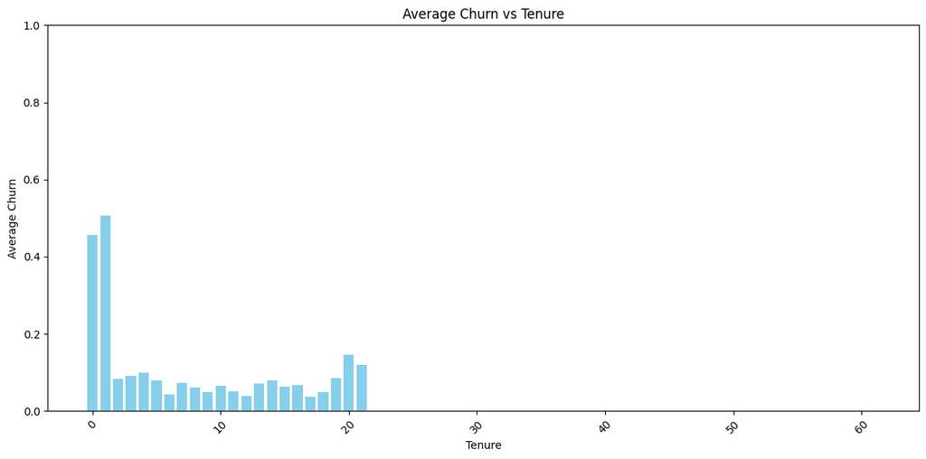

```python
import matplotlib.pyplot as plt
average_churn = data_encoded.groupby('Tenure')['Churn'].mean().reset_index()

# Create a larger figure
plt.figure(figsize=(12, 6))  # Adjust width and height as needed

# Create a bar plot
plt.bar(average_churn['Tenure'], average_churn['Churn'], color='skyblue')
plt.xlabel('Tenure')
plt.ylabel('Average Churn')
plt.title('Average Churn vs Tenure')
plt.xticks(rotation=45)  # Rotate x-axis labels for better readability

# Optionally, set y-axis limits if needed
plt.ylim(0, 1)  # Assuming churn is binary (0 or 1)

plt.tight_layout()  # Adjust layout to make room for labels
plt.show()
```

Correlation Testing: Use correlation to check for linear relationships between numeric features.

```python
# Now you can calculate the correlation matrix
correlation_matrix = data_encoded.corr()

# Display correlations with 'Churn'
print(correlation_matrix['Churn'].sort_values(ascending=False))
```

```
Churn                                    1.000000
Complain                                 0.250188
MaritalStatus_Single                     0.180847
PreferedOrderCat_Mobile Phone            0.154387
PreferedOrderCat_Mobile                  0.113364
NumberOfDeviceRegistered                 0.107939
SatisfactionScore                        0.105481
PreferredPaymentMode_COD                 0.083933
CityTier_3                               0.080395
PreferredLoginDevice_Phone               0.078916
PreferredPaymentMode_E wallet            0.055751
NumberOfAddress                          0.043931
OrderAmountHikeFromlastYear              0.039369
WarehouseToHome                          0.033889
Gender_Male                              0.029264
CityTier_2                               0.016970
CouponUsed                               0.007425
PreferredPaymentMode_UPI                 0.004163
PreferredPaymentMode_Cash on Delivery   -0.006178
HourSpendOnApp                          -0.008768
OrderCount                              -0.015327
CustomerID                              -0.019083
PreferredPaymentMode_Debit Card         -0.032453
PreferedOrderCat_Others                 -0.054903
PreferredPaymentMode_Credit Card        -0.064131
PreferedOrderCat_Grocery                -0.089575
PreferredLoginDevice_Mobile Phone       -0.111639
PreferedOrderCat_Laptop & Accessory     -0.133353
MaritalStatus_Married                   -0.151024
DaySinceLastOrder                       -0.151303
CashbackAmount                          -0.154161
Tenure                                  -0.345374
Name: Churn, dtype: float64
```

# Pairwise Correlations and Heatmap: Identify strong correlations between variables (Additional Technique)

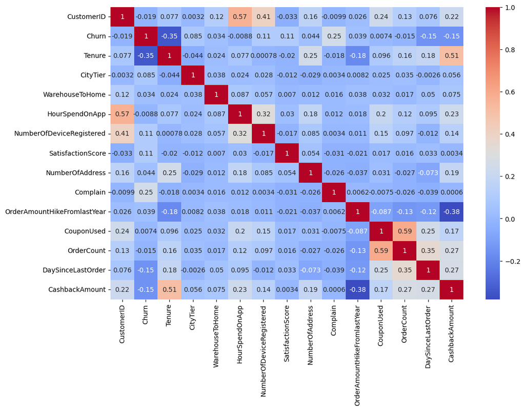

```python
import pandas as pd
import seaborn as sns
import matplotlib.pyplot as plt

# Drop non-numeric columns
numeric_data = data.select_dtypes(include='number')

# Compute correlation matrix
correlation_matrix = numeric_data.corr()
plt.figure(figsize=(12, 8))

# Plot the heatmap
sns.heatmap(correlation_matrix, annot=True, cmap='coolwarm')

# Show the heatmap
plt.show()
```

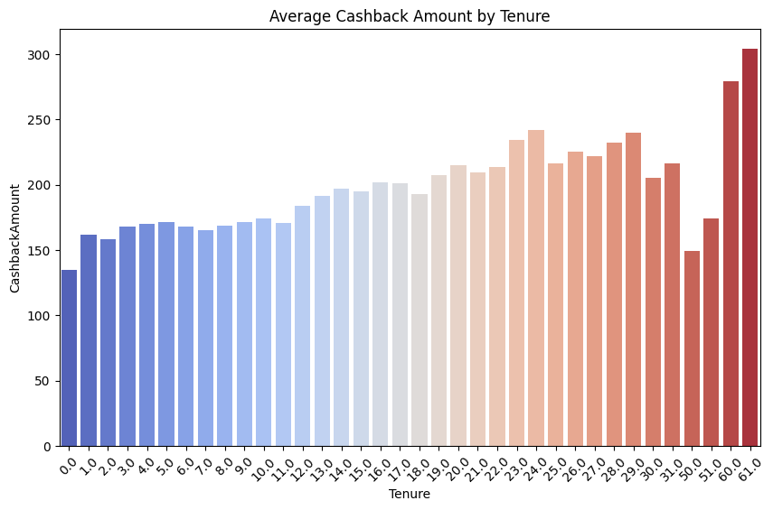

```python
import seaborn as sns
import matplotlib.pyplot as plt

# Group data by 'Tenure' and calculate mean CashbackAmount
tenure_cashback = data.groupby('Tenure')['CashbackAmount'].mean().reset_index()

plt.figure(figsize=(10, 6))
sns.barplot(x='Tenure', y='CashbackAmount', data=tenure_cashback, palette='coolwarm')
plt.title('Average Cashback Amount by Tenure')
plt.xticks(rotation=45)  # Rotate x-axis labels for better visibility if needed
plt.show()
```

*Key Observations from the Cashback Amount by Tenure Plot

*Increasing Cashback Amount with Tenure:

*Significant Jumps:

-Sharp increases in cashback around 20-25 months and at 60 months indicate possible loyalty rewards.

*Consistent Levels for Shorter Tenure:

-Cashback remains stable (150-200 units) for customers with tenure under 15 months.

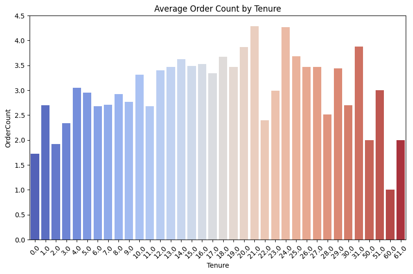

```python
# Group data by 'Tenure' and calculate mean OrderCount
tenure_order = data.groupby('Tenure')['OrderCount'].mean().reset_index()

plt.figure(figsize=(10, 6))
sns.barplot(x='Tenure', y='OrderCount', data=tenure_order, palette='coolwarm')
plt.title('Average Order Count by Tenure')
plt.xticks(rotation=45)
plt.show()
```

*Key Observations:

*Marketing Insights:

-Engagement: Offer promotions to new customers (first 10 months).

-Reactivation: Launch campaigns for long-tenured customers showing disengagement.

*Analysis Suggestions:

-Segment analysis of churned vs. non-churned customers.

-Cumulative orders visualization over time.

-Correlation exploration between tenure, order count, and other variables.

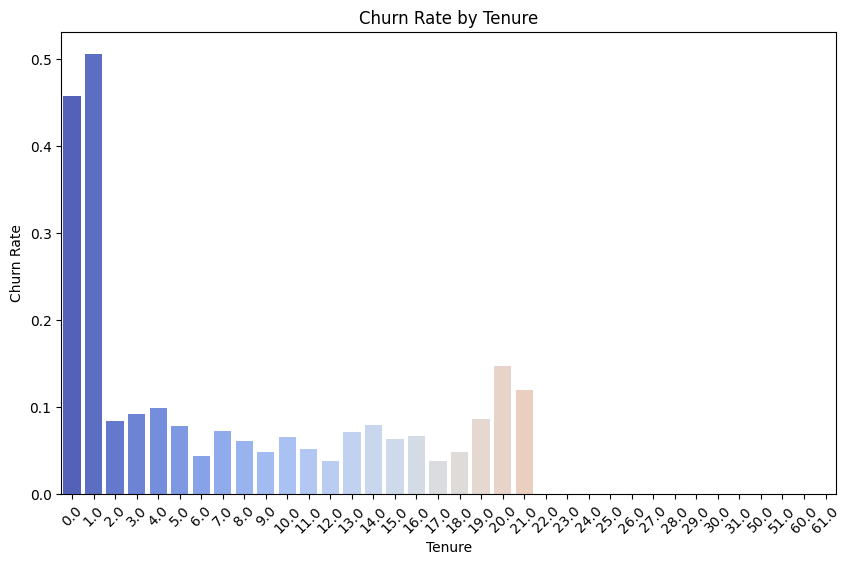

```python
# Group data by 'Tenure' and calculate mean Churn rate
churn_rate = data.groupby('Tenure')['Churn'].mean().reset_index()

plt.figure(figsize=(10, 6))
sns.barplot(x='Tenure', y='Churn', data=churn_rate, palette='coolwarm')
plt.title('Churn Rate by Tenure')
plt.xticks(rotation=45)
plt.ylabel('Churn Rate')
plt.show()
```

Key Insights & Recommendations:

High churn in the first month: Over 50% of customers leave early, indicating dissatisfaction.

Churn stabilizes after 3 months: Customers staying past this period are more likely to continue.

Spike at 20-22 months: Churn increases again, likely due to pricing or service fatigue.

Recommendations:

Improve onboarding to reduce early churn.

Offer loyalty rewards at key milestones.

Investigate the 20-month churn spike for targeted solutions.

1. Churn vs. Cashback Amount:

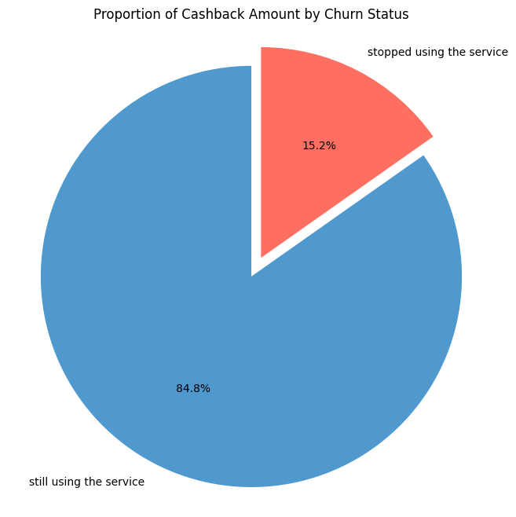

```python
import matplotlib.pyplot as plt
import pandas as pd

# Assuming df is your dataframe
# Group the data by 'Churn' and sum the CashbackAmount for churned and non-churned customers
cashback_by_churn = data.groupby('Churn')['CashbackAmount'].sum()

# Plot a pie chart of CashbackAmount by Churn
plt.figure(figsize=(8, 8))
plt.pie(cashback_by_churn, labels=['still using the service', 'stopped using the service'], autopct='%1.1f%%', colors=['#4f99cf', '#ff6f61'], startangle=90, explode=[0, 0.1])

# Set title
plt.title('Proportion of Cashback Amount by Churn Status')
plt.axis('equal')  # Equal aspect ratio ensures that pie is drawn as a circle.
plt.show()
```

Analysis:

To reduce churn, we should analyze why these customers left focusing on retention programs like loyalty rewards, and tailor offers based on customer behavior to keep more customers engaged and prevent further churn.

1. Cashback Amount and Customer Lifetime Value (LTV) Correlation:

LTV can be calculated using various methods, often incorporating average purchase value, purchase frequency, and customer lifespan. A simple formula is:

LTV=Average Order Value×Purchase Frequency×Customer Lifespan

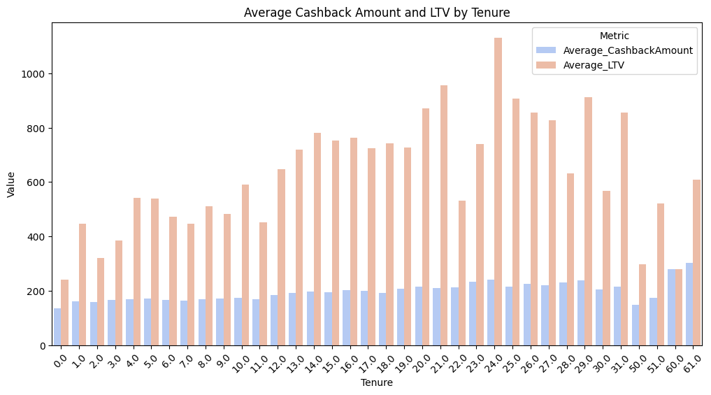

```python
import matplotlib.pyplot as plt
import seaborn as sns
import pandas as pd

# Assuming your dataframe is named df, adjust if needed
# Create a new column for LTV
data['LTV'] = data['OrderCount'] * data['CashbackAmount']

# Group by Tenure and calculate average CashbackAmount and LTV
summary_df = data.groupby('Tenure').agg(
    Average_CashbackAmount=('CashbackAmount', 'mean'),
    Average_LTV=('LTV', 'mean')
).reset_index()

# Melt the dataframe for easier plotting
melted_df = summary_df.melt(id_vars='Tenure', value_vars=['Average_CashbackAmount', 'Average_LTV'],
                             var_name='Metric', value_name='Value')

# Set up the bar plot
plt.figure(figsize=(12, 6))
sns.barplot(x='Tenure', y='Value', hue='Metric', data=melted_df, palette='coolwarm')

# Set labels and title
plt.title('Average Cashback Amount and LTV by Tenure')
plt.xlabel('Tenure')
plt.ylabel('Value')
plt.legend(title='Metric')
plt.xticks(rotation=45)
plt.show()
```

Overall, tailored strategies for each tenure group can help maximize LTV at key points in the customer lifecycle.

Promotion Effectiveness:

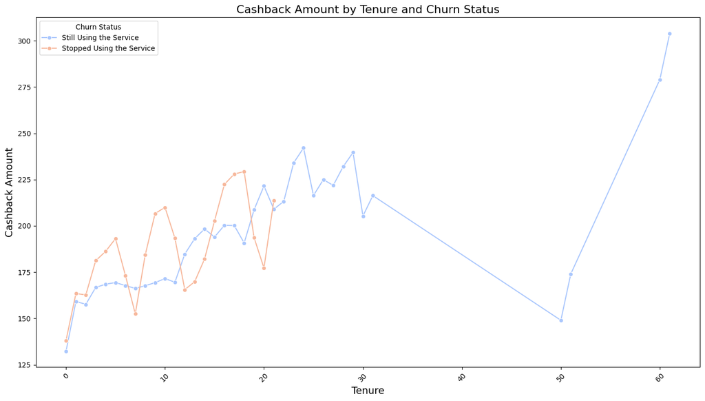

```python
import matplotlib.pyplot as plt
import seaborn as sns

# Assuming your dataframe is named data
# Set figure size
plt.figure(figsize=(14, 8))

# Create a line plot for Cashback Amount by Tenure and Churn Status with custom labels
sns.lineplot(data=data, x='Tenure', y='CashbackAmount', hue='Churn',
             palette='coolwarm', marker='o', ci=None)

# Update legend labels
handles, labels = plt.gca().get_legend_handles_labels()
new_labels = ['Still Using the Service', 'Stopped Using the Service']
plt.legend(handles, new_labels, title='Churn Status')

# Set labels and title
plt.title('Cashback Amount by Tenure and Churn Status', fontsize=16)
plt.xlabel('Tenure', fontsize=14)
plt.ylabel('Cashback Amount', fontsize=14)
plt.xticks(rotation=45)  # Rotate x-axis labels for better visibility
plt.tight_layout()  # Adjust layout to prevent clipping
plt.show()
```

#### 3. Modeling

a. Train-Test Split:

Split the data into training and testing sets (80% train, 20% test).

```python
pip install scikit-learn
```

```python
import pandas as pd
from sklearn.model_selection import train_test_split
from sklearn.preprocessing import StandardScaler, OneHotEncoder
from sklearn.compose import ColumnTransformer
from sklearn.pipeline import Pipeline
from sklearn.tree import DecisionTreeClassifier
from sklearn.linear_model import LogisticRegression
from sklearn.metrics import classification_report, confusion_matrix, accuracy_score

# Assuming 'data' is your DataFrame
X = data.drop('Churn', axis=1)  # Features
y = data['Churn']  # Target variable

# Identify categorical and numerical columns
categorical_cols = X.select_dtypes(include=['object']).columns.tolist()
numerical_cols = X.select_dtypes(exclude=['object']).columns.tolist()

# Create a ColumnTransformer to apply OneHotEncoder to categorical columns
preprocessor = ColumnTransformer(
    transformers=[
        ('num', StandardScaler(), numerical_cols),  # Scale numerical features
        ('cat', OneHotEncoder(), categorical_cols)   # One-hot encode categorical features
    ])

# Split the data into training and testing sets
X_train, X_test, y_train, y_test = train_test_split(X, y, test_size=0.20, random_state=42)

# Fit the preprocessor on the training data and transform it
X_train_processed = preprocessor.fit_transform(X_train)
X_test_processed = preprocessor.transform(X_test)
```

```python
# Initialize and train the Decision Tree model
decision_tree_model = DecisionTreeClassifier(random_state=42)
decision_tree_model.fit(X_train_processed, y_train)

# Make predictions
y_pred_tree = decision_tree_model.predict(X_test_processed)

# Evaluate the Decision Tree model
print("Decision Tree Model Accuracy:", accuracy_score(y_test, y_pred_tree))
print("Classification Report:\n", classification_report(y_test, y_pred_tree))
print("Confusion Matrix:\n", confusion_matrix(y_test, y_pred_tree))
```

```
Decision Tree Model Accuracy: 0.9644760213143873
Classification Report:
               precision    recall  f1-score   support

           0       0.98      0.98      0.98       941
           1       0.90      0.88      0.89       185

    accuracy                           0.96      1126
   macro avg       0.94      0.93      0.93      1126
weighted avg       0.96      0.96      0.96      1126

Confusion Matrix:
 [[923  18]
 [ 22 163]]
```

Decision Tree Model Results Interpretation

1. Accuracy Accuracy: 96.4% indicates that the model correctly predicts whether a customer will churn or not for approximately 96.4% of the cases in the test dataset. This is an excellent accuracy rate, suggesting that the model is effective at distinguishing between churned and non-churned customers.
2. Classification Report The classification report provides detailed metrics for each class (0 for non-churned, 1 for churned).

Precision:

For Non-Churned Customers (0): 98% means that when the model predicts a customer will not churn, it is correct 98% of the time. For Churned Customers (1): 90% means that when the model predicts a customer will churn, it is correct 90% of the time. This is still high but indicates that there may be some misclassification of churned customers. Recall:

For Non-Churned Customers (0): 98% indicates that out of all actual non-churned customers, 98% were correctly identified as such by the model. For Churned Customers (1): 88% indicates that out of all actual churned customers, 88% were correctly identified. This means there is a small percentage of churned customers (12%) that were missed (false negatives). F1 Score:

For Non-Churned Customers (0): 98% indicates a strong balance between precision and recall for non-churned customers. For Churned Customers (1): 89% indicates a good balance between precision and recall but suggests that there’s room for improvement, especially in identifying churned customers. Macro and Weighted Averages:

Macro Average: This takes the average of precision, recall, and F1 score without considering class imbalance. The values (94% precision, 93% recall, and 93% F1 score) suggest the model performs well on average across classes. Weighted Average: This accounts for the number of instances in each class, which is useful when the classes are imbalanced. Here, the weighted averages are very close to the metrics for non-churned customers, indicating that the model is performing very well overall.

True Positives (TP): 163 customers were correctly predicted as churned.

True Negatives (TN): 923 customers were correctly predicted as not churned.

False Positives (FP): 18 customers were incorrectly predicted as churned (they did not churn).

False Negatives (FN): 22 customers were incorrectly predicted as not churned (they actually churned).

summary

High Accuracy: The model performs exceptionally well overall, but it is crucial to note that while the accuracy is high, the recall for churned customers (1) is slightly lower (88%). This suggests that some churners are being missed by the model.

Balanced Precision and Recall: The model has a strong precision for both classes, meaning that when it makes a prediction, it is likely correct.

Actionable Insights:

Focus on the group of churned customers that were misclassified (the 22 false negatives) to understand what characteristics they share. This can help refine future models and improve marketing strategies. Consider investigating the features that most contribute to the decision-making process in the tree to understand which factors are influencing churn. This could guide targeted interventions.

```python
# Initialize and train the Logistic Regression model
logistic_model = LogisticRegression(random_state=42, max_iter=1000)
logistic_model.fit(X_train_processed, y_train)

# Make predictions
y_pred_logistic = logistic_model.predict(X_test_processed)

# Evaluate the Logistic Regression model
print("Logistic Regression Model Accuracy:", accuracy_score(y_test, y_pred_logistic))
print("Classification Report:\n", classification_report(y_test, y_pred_logistic))
print("Confusion Matrix:\n", confusion_matrix(y_test, y_pred_logistic))
```

```
Logistic Regression Model Accuracy: 0.9076376554174067
Classification Report:
               precision    recall  f1-score   support

           0       0.91      0.98      0.95       941
           1       0.85      0.53      0.65       185

    accuracy                           0.91      1126
   macro avg       0.88      0.76      0.80      1126
weighted avg       0.90      0.91      0.90      1126

Confusion Matrix:
 [[924  17]
 [ 87  98]]
```

Logistic Regression Model Results Interpretation

1. Accuracy Accuracy: 90.8% indicates that the model correctly predicts whether a customer will churn or not for approximately 90.8% of the cases in the test dataset. While this is still a strong performance, it is notably lower than the 96.4% accuracy achieved by the Decision Tree model.
2. Classification Report The classification report provides detailed metrics for each class (0 for non-churned, 1 for churned).

Precision:

For Non-Churned Customers (0): 91% means that when the model predicts a customer will not churn, it is correct 91% of the time. For Churned Customers (1): 85% indicates that when the model predicts a customer will churn, it is correct 85% of the time. While this is reasonable, it is lower than the 90% precision of the Decision Tree. Recall:

For Non-Churned Customers (0): 98% suggests that out of all actual non-churned customers, 98% were correctly identified as such. This is consistent with the Decision Tree model. For Churned Customers (1): 53% indicates that only 53% of actual churned customers were identified by the model. This is significantly lower than the Decision Tree’s 88% recall, suggesting that Logistic Regression has a higher number of false negatives. F1 Score:

For Non-Churned Customers (0): 95% indicates a strong balance between precision and recall for non-churned customers, similar to the Decision Tree. For Churned Customers (1): 65% indicates that the model struggles to balance precision and recall for churned customers, reflecting its lower ability to identify them correctly compared to the Decision Tree. Macro and Weighted Averages:

Macro Average: This shows a lower performance compared to the Decision Tree, indicating poorer balance across classes. Specifically, with an F1 score of 80%, it suggests that the model is less effective on average across both classes. Weighted Average: The weighted averages are higher than the macro average, reflecting that the non-churned class has a larger representation in the data.

True Positives (TP): 98 customers were correctly predicted as churned.

True Negatives (TN): 924 customers were correctly predicted as not churned.

False Positives (FP): 17 customers were incorrectly predicted as churned (they did not churn).

False Negatives (FN): 87 customers were incorrectly predicted as not churned (they actually churned). This is significantly higher than the 22 false negatives from the Decision Tree model.

1. Performance Comparison:

Accuracy: The Decision Tree model outperforms Logistic Regression (96.4% vs. 90.8%). Precision and Recall: The Decision Tree provides higher precision and recall for churned customers (1). Logistic Regression shows a significant drop in recall for this group, indicating more missed churners. F1 Score: The F1 score for churned customers is notably lower in Logistic Regression (65% vs. 89%), suggesting that this model is less effective at identifying customers who are likely to churn.

1. Business Implications:

Risk of Churn Identification: Since the Logistic Regression model has a high number of false negatives, it might miss a significant number of customers who are likely to churn, which can lead to lost opportunities in retention strategies. Model Selection: Based on the higher accuracy, precision, recall, and F1 score for churned customers, the Decision Tree model may be preferred for identifying at-risk customers.